# Dataframe_Import_Example

```python
import numpy as np
import pandas as pd
import matplotlib.pyplot as plt
import seaborn as sns

color = 'RdBu'
```

```python
files = ['xaa.dat', 'xab.dat', 'xac.dat', 'xad.dat', 'xae.dat', 'xaf.dat', 'xag.dat', 'xah.dat', 'xai.dat']
attributes = ['Compactness', 'Circularity', 'Dist_Circ', 'Radius_Ratio', 'PR_Axis_Ratio', 'Max_Length_Ratio', 'Scatter_Ratio',
             'Enlongatedness', 'PR_Axis_Rectangularity', 'Max_Length_Rectangularity', 'Major_Scaled_Var', 'Minor_Scaled_Var',
             'Scaled Radius Gyration', 'Major_Skew', 'Minor_Skew', 'Minor_Kurtosis', 'Major_Kurtosis', 'Hollow_Ratio',
             'Vehicle_Type']
car_types = ['van', 'saab', 'bus', 'opel']
```

```python
vehicle_df = pd.DataFrame(columns=attributes)
for file in files:
    f = open(file, 'r')
    for line in f:
        l = line.strip().split(' ')
        vehicle_df.loc[len(vehicle_df.index)] = list(map(lambda i: i if i in car_types else int(i), l))
```

```python
for attribute in [att for att in attributes if att != 'Vehicle_Type']:
    vehicle_df[attribute] = vehicle_df[attribute].astype('int')
```

```python
vehicle_df.head()
```

|  | Compactness | Circularity | Dist_Circ | Radius_Ratio | PR_Axis_Ratio | Max_Length_Ratio | Scatter_Ratio | Enlongatedness | PR_Axis_Rectangularity | Max_Length_Rectangularity | Major_Scaled_Var | Minor_Scaled_Var | Scaled Radius Gyration | Major_Skew | Minor_Skew | Minor_Kurtosis | Major_Kurtosis | Hollow_Ratio | Vehicle_Type |
| --- | --- | --- | --- | --- | --- | --- | --- | --- | --- | --- | --- | --- | --- | --- | --- | --- | --- | --- | --- |
| 0 | 95 | 48 | 83 | 178 | 72 | 10 | 162 | 42 | 20 | 159 | 176 | 379 | 184 | 70 | 6 | 16 | 187 | 197 | van |
| 1 | 91 | 41 | 84 | 141 | 57 | 9 | 149 | 45 | 19 | 143 | 170 | 330 | 158 | 72 | 9 | 14 | 189 | 199 | van |
| 2 | 104 | 50 | 106 | 209 | 66 | 10 | 207 | 32 | 23 | 158 | 223 | 635 | 220 | 73 | 14 | 9 | 188 | 196 | saab |
| 3 | 93 | 41 | 82 | 159 | 63 | 9 | 144 | 46 | 19 | 143 | 160 | 309 | 127 | 63 | 6 | 10 | 199 | 207 | van |
| 4 | 85 | 44 | 70 | 205 | 103 | 52 | 149 | 45 | 19 | 144 | 241 | 325 | 188 | 127 | 9 | 11 | 180 | 183 | bus |

```python
vehicle_df.describe()
```

|  | Compactness | Circularity | Dist_Circ | Radius_Ratio | PR_Axis_Ratio | Max_Length_Ratio | Scatter_Ratio | Enlongatedness | PR_Axis_Rectangularity | Max_Length_Rectangularity | Major_Scaled_Var | Minor_Scaled_Var | Scaled Radius Gyration | Major_Skew | Minor_Skew | Minor_Kurtosis | Major_Kurtosis | Hollow_Ratio |
| --- | --- | --- | --- | --- | --- | --- | --- | --- | --- | --- | --- | --- | --- | --- | --- | --- | --- | --- |
| count | 846.000000 | 846.000000 | 846.000000 | 846.000000 | 846.000000 | 846.000000 | 846.000000 | 846.000000 | 846.000000 | 846.000000 | 846.000000 | 846.000000 | 846.00000 | 846.000000 | 846.000000 | 846.000000 | 846.000000 | 846.000000 |
| mean | 93.678487 | 44.861702 | 82.088652 | 168.940898 | 61.693853 | 8.567376 | 168.839243 | 40.933806 | 20.582742 | 147.998818 | 188.625296 | 439.911348 | 174.70331 | 72.462175 | 6.377069 | 12.599291 | 188.932624 | 195.632388 |
| std | 8.234474 | 6.169866 | 15.771533 | 33.472183 | 7.888251 | 4.601217 | 33.244978 | 7.811560 | 2.592138 | 14.515652 | 31.394837 | 176.692614 | 32.54649 | 7.486974 | 4.918353 | 8.931240 | 6.163949 | 7.438797 |
| min | 73.000000 | 33.000000 | 40.000000 | 104.000000 | 47.000000 | 2.000000 | 112.000000 | 26.000000 | 17.000000 | 118.000000 | 130.000000 | 184.000000 | 109.00000 | 59.000000 | 0.000000 | 0.000000 | 176.000000 | 181.000000 |
| 25% | 87.000000 | 40.000000 | 70.000000 | 141.000000 | 57.000000 | 7.000000 | 146.250000 | 33.000000 | 19.000000 | 137.000000 | 167.000000 | 318.250000 | 149.00000 | 67.000000 | 2.000000 | 5.000000 | 184.000000 | 190.250000 |
| 50% | 93.000000 | 44.000000 | 80.000000 | 167.000000 | 61.000000 | 8.000000 | 157.000000 | 43.000000 | 20.000000 | 146.000000 | 178.500000 | 364.000000 | 173.00000 | 71.500000 | 6.000000 | 11.000000 | 188.000000 | 197.000000 |
| 75% | 100.000000 | 49.000000 | 98.000000 | 195.000000 | 65.000000 | 10.000000 | 198.000000 | 46.000000 | 23.000000 | 159.000000 | 217.000000 | 587.000000 | 198.00000 | 75.000000 | 9.000000 | 19.000000 | 193.000000 | 201.000000 |
| max | 119.000000 | 59.000000 | 112.000000 | 333.000000 | 138.000000 | 55.000000 | 265.000000 | 61.000000 | 29.000000 | 188.000000 | 320.000000 | 1018.000000 | 268.00000 | 135.000000 | 22.000000 | 41.000000 | 206.000000 | 211.000000 |

```python
vehicle_df.info()
```

```
<class 'pandas.core.frame.DataFrame'>
Int64Index: 846 entries, 0 to 845
Data columns (total 19 columns):
 #   Column                     Non-Null Count  Dtype
---  ------                     --------------  -----
 0   Compactness                846 non-null    int32
 1   Circularity                846 non-null    int32
 2   Dist_Circ                  846 non-null    int32
 3   Radius_Ratio               846 non-null    int32
 4   PR_Axis_Ratio              846 non-null    int32
 5   Max_Length_Ratio           846 non-null    int32
 6   Scatter_Ratio              846 non-null    int32
 7   Enlongatedness             846 non-null    int32
 8   PR_Axis_Rectangularity     846 non-null    int32
 9   Max_Length_Rectangularity  846 non-null    int32
 10  Major_Scaled_Var           846 non-null    int32
 11  Minor_Scaled_Var           846 non-null    int32
 12  Scaled Radius Gyration     846 non-null    int32
 13  Major_Skew                 846 non-null    int32
 14  Minor_Skew                 846 non-null    int32
 15  Minor_Kurtosis             846 non-null    int32
 16  Major_Kurtosis             846 non-null    int32
 17  Hollow_Ratio               846 non-null    int32
 18  Vehicle_Type               846 non-null    object
dtypes: int32(18), object(1)
memory usage: 72.7+ KB
```

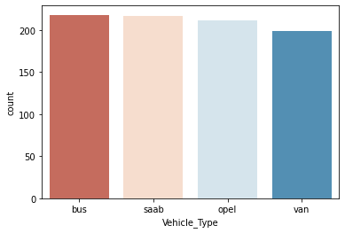

```python
count = vehicle_df['Vehicle_Type'].value_counts()
sns.countplot(x=vehicle_df['Vehicle_Type'], order=count.index,  palette=color)
plt.show()
```

```python
#Hot encloding the target variable
from sklearn.preprocessing import LabelEncoder

labelencoder = LabelEncoder()
vehicle_df['Vehicle_Type'] = labelencoder.fit_transform(vehicle_df['Vehicle_Type'])
vehicle_df['Vehicle_Type'].value_counts()
```

```
0    218
2    217
1    212
3    199
Name: Vehicle_Type, dtype: int64
```

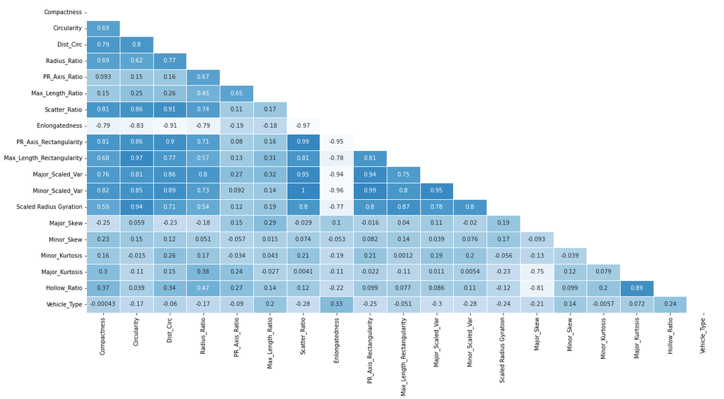

```python
# Compute the correlation matrix
corr = vehicle_df.corr()
lower_triangle = np.tril(corr, k = -1)

# Generate a mask for the upper triangle
mask = np.triu(np.ones_like(corr, dtype=bool))

plt.figure(figsize = (20,10))

# Generate a custom diverging colormap
cmap = sns.diverging_palette(210, 20, as_cmap=True)

# Draw the heatmap with the mask and correct aspect ratio
sns.heatmap(lower_triangle, center=0.5, cmap= 'Blues', annot= True, xticklabels = corr.index, yticklabels = corr.columns,
            cbar= False, linewidths= 1, mask = mask)

plt.show()
```

Interpretations: There are high correleations among variables. Correlation index between 'Minor_Scaled_Var' and 'Scatter_Ratio" is even 1. Since there are many highly correlated variables, We will use PCA to reduce the dimensionality.

```python
# Check for outliers, but only on training data

from sklearn.model_selection import train_test_split

X_train, X_test = train_test_split(vehicle_df, test_size=0.3, random_state=7)
```

```python
def handleOutlier(aSeries):

    q1 = aSeries.quantile(0.25)
    q3 = aSeries.quantile(0.75)

    iqr = q3-q1 #Interquartile range
    fence_low  = q1-1.5*iqr
    fence_high = q3+1.5*iqr
    outliers_low = aSeries[(aSeries < fence_low)]
    outliers_high= aSeries[(aSeries > fence_high)]

    print ("25th Quantile value: ", q1)
    print('Outlier low Count =', outliers_low.count())
    print('List of Low outliers: \n')
    print(outliers_low)

    print ("75th Quantile value: ", q3)
    print('Outlier High Count = ', outliers_high.count())
    print('List of High outliers: \n')
    print(outliers_high)
```

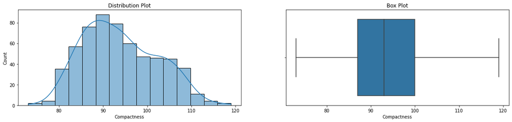

```python
fig,(ax1,ax2) = plt.subplots(nrows=1,ncols=2)
fig.set_size_inches(20,4)
sns.histplot(data=X_train,x=X_train['Compactness'],ax=ax1,kde=True)
ax1.set_title("Distribution Plot")

sns.boxplot(data=X_train,x=X_train['Compactness'],ax=ax2)
ax2.set_title("Box Plot")

plt.show()
```

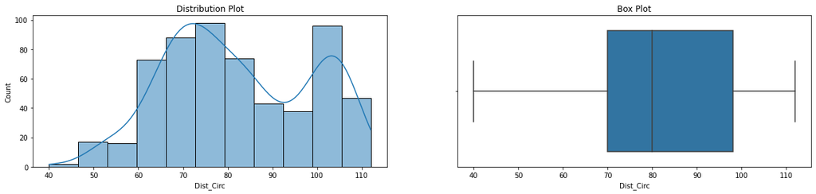

```python
fig,(ax1,ax2) = plt.subplots(nrows=1,ncols=2)
fig.set_size_inches(20,4)
sns.histplot(data=X_train, x=X_train['Dist_Circ'],ax=ax1,kde=True)
ax1.set_title("Distribution Plot")

sns.boxplot(data=X_train, x=X_train['Dist_Circ'],ax=ax2)
ax2.set_title("Box Plot")

plt.show()
```

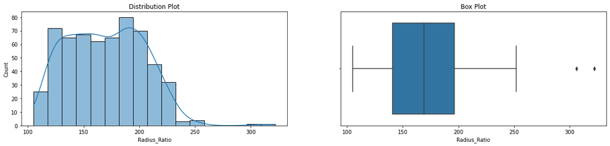

```python
fig,(ax1,ax2) = plt.subplots(nrows=1,ncols=2)
fig.set_size_inches(20,4)
sns.histplot(data=X_train,kde=True,x=X_train['Radius_Ratio'],ax=ax1,)
ax1.set_title("Distribution Plot")

sns.boxplot(data=X_train,x=X_train['Radius_Ratio'],ax=ax2)
ax2.set_title("Box Plot")

plt.show()
```

There are some outliers in radius_ratio.

```python
handleOutlier(X_train['Radius_Ratio'])
```

```
25th Quantile value:  141.0
Outlier low Count = 0
List of Low outliers:

Series([], Name: Radius_Ratio, dtype: int32)
75th Quantile value:  196.25
Outlier High Count =  2
List of High outliers:

37     306
135    322
Name: Radius_Ratio, dtype: int32
```

```python
# check the complete 2 rows
X_train.loc[[37, 135]]
```

|  | Compactness | Circularity | Dist_Circ | Radius_Ratio | PR_Axis_Ratio | Max_Length_Ratio | Scatter_Ratio | Enlongatedness | PR_Axis_Rectangularity | Max_Length_Rectangularity | Major_Scaled_Var | Minor_Scaled_Var | Scaled Radius Gyration | Major_Skew | Minor_Skew | Minor_Kurtosis | Major_Kurtosis | Hollow_Ratio | Vehicle_Type |
| --- | --- | --- | --- | --- | --- | --- | --- | --- | --- | --- | --- | --- | --- | --- | --- | --- | --- | --- | --- |
| 37 | 90 | 48 | 86 | 306 | 126 | 49 | 153 | 44 | 19 | 156 | 272 | 346 | 200 | 118 | 0 | 15 | 185 | 194 | 3 |
| 135 | 89 | 47 | 83 | 322 | 133 | 48 | 158 | 43 | 20 | 163 | 229 | 364 | 176 | 97 | 0 | 14 | 184 | 194 | 3 |

```python
X_train[X_train['Vehicle_Type']==3]['Radius_Ratio'].sort_values(ascending=False).head()
```

```
135    322
37     306
706    250
291    246
523    231
Name: Radius_Ratio, dtype: int32
```

The two rows have high values compared to their next lower value. We will treat this as outliers and replace their values with max values.

```python
X_train.loc[[37,135],'Radius_Ratio']=250.0
```

```python
# double checking
X_train.loc[[37,135]]
```

|  | Compactness | Circularity | Dist_Circ | Radius_Ratio | PR_Axis_Ratio | Max_Length_Ratio | Scatter_Ratio | Enlongatedness | PR_Axis_Rectangularity | Max_Length_Rectangularity | Major_Scaled_Var | Minor_Scaled_Var | Scaled Radius Gyration | Major_Skew | Minor_Skew | Minor_Kurtosis | Major_Kurtosis | Hollow_Ratio | Vehicle_Type |
| --- | --- | --- | --- | --- | --- | --- | --- | --- | --- | --- | --- | --- | --- | --- | --- | --- | --- | --- | --- |
| 37 | 90 | 48 | 86 | 250 | 126 | 49 | 153 | 44 | 19 | 156 | 272 | 346 | 200 | 118 | 0 | 15 | 185 | 194 | 3 |
| 135 | 89 | 47 | 83 | 250 | 133 | 48 | 158 | 43 | 20 | 163 | 229 | 364 | 176 | 97 | 0 | 14 | 184 | 194 | 3 |

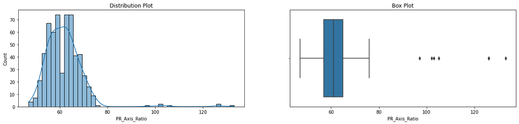

```python
fig,(ax1,ax2) = plt.subplots(nrows=1,ncols=2)
fig.set_size_inches(20,4)
sns.histplot(data=X_train,kde=True,x=X_train['PR_Axis_Ratio'],ax=ax1)
ax1.set_title("Distribution Plot")

sns.boxplot(data=X_train,x=X_train['PR_Axis_Ratio'],ax=ax2)
ax2.set_title("Box Plot")

plt.show()
```

There are some ouliers needed to handle.

```python
 handleOutlier(X_train['PR_Axis_Ratio'])
```

```
25th Quantile value:  57.0
Outlier low Count = 0
List of Low outliers:

Series([], Name: PR_Axis_Ratio, dtype: int32)
75th Quantile value:  65.0
Outlier High Count =  7
List of High outliers:

523     97
37     126
706    105
291    102
135    133
4      103
100    126
Name: PR_Axis_Ratio, dtype: int32
```

```python
X_train.loc[[523,37,706,291,135,4,100]]
```

|  | Compactness | Circularity | Dist_Circ | Radius_Ratio | PR_Axis_Ratio | Max_Length_Ratio | Scatter_Ratio | Enlongatedness | PR_Axis_Rectangularity | Max_Length_Rectangularity | Major_Scaled_Var | Minor_Scaled_Var | Scaled Radius Gyration | Major_Skew | Minor_Skew | Minor_Kurtosis | Major_Kurtosis | Hollow_Ratio | Vehicle_Type |
| --- | --- | --- | --- | --- | --- | --- | --- | --- | --- | --- | --- | --- | --- | --- | --- | --- | --- | --- | --- |
| 523 | 90 | 43 | 81 | 231 | 97 | 46 | 150 | 45 | 19 | 149 | 200 | 332 | 164 | 91 | 5 | 9 | 186 | 196 | 3 |
| 37 | 90 | 48 | 86 | 250 | 126 | 49 | 153 | 44 | 19 | 156 | 272 | 346 | 200 | 118 | 0 | 15 | 185 | 194 | 3 |
| 706 | 82 | 43 | 70 | 250 | 105 | 55 | 139 | 48 | 18 | 145 | 231 | 289 | 172 | 99 | 4 | 9 | 190 | 199 | 3 |
| 291 | 89 | 45 | 81 | 246 | 102 | 43 | 155 | 44 | 20 | 160 | 200 | 347 | 177 | 90 | 9 | 17 | 183 | 192 | 3 |
| 135 | 89 | 47 | 83 | 250 | 133 | 48 | 158 | 43 | 20 | 163 | 229 | 364 | 176 | 97 | 0 | 14 | 184 | 194 | 3 |
| 4 | 85 | 44 | 70 | 205 | 103 | 52 | 149 | 45 | 19 | 144 | 241 | 325 | 188 | 127 | 9 | 11 | 180 | 183 | 0 |
| 100 | 82 | 45 | 66 | 252 | 126 | 52 | 148 | 45 | 19 | 144 | 237 | 326 | 185 | 119 | 1 | 1 | 181 | 185 | 0 |

Rows at index 4 and 100 are bus while the rest is van.

```python
# Lets Check for Bus first
X_train[X_train['Vehicle_Type']==0]['PR_Axis_Ratio'].sort_values( ascending=False).head(8)
```

```
100    126
4      103
84      76
556     75
275     75
88      75
450     75
151     74
Name: PR_Axis_Ratio, dtype: int32
```

We will drop them because it's significantly higher than the max value.

```python
# dropping 4, 100
X_train.drop([4,100], inplace=True)
```

```python
# Now check for van
X_train[X_train['Vehicle_Type']==3]['PR_Axis_Ratio'].sort_values( ascending=False).head(15)
```

```
135    133
37     126
706    105
291    102
523     97
0       72
149     69
732     69
722     68
68      68
457     68
449     68
234     68
35      67
572     67
Name: PR_Axis_Ratio, dtype: int32
```

```python
X_train.drop([37,135,291,523,706], inplace=True)
```

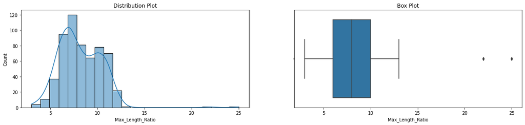

```python
fig,(ax1,ax2) = plt.subplots(nrows=1,ncols=2)
fig.set_size_inches(20,4)
sns.histplot(data=X_train,kde=True,x=X_train['Max_Length_Ratio'],ax=ax1)
ax1.set_title("Distribution Plot")

sns.boxplot(data=X_train,x=X_train['Max_Length_Ratio'],ax=ax2)
ax2.set_title("Box Plot")

plt.show()
```

```python
 handleOutlier(X_train['Max_Length_Ratio'])
```

```
25th Quantile value:  6.0
Outlier low Count = 0
List of Low outliers:

Series([], Name: Max_Length_Ratio, dtype: int32)
75th Quantile value:  10.0
Outlier High Count =  2
List of High outliers:

815    22
391    25
Name: Max_Length_Ratio, dtype: int32
```

```python
X_train.loc[[815,391]]
```

|  | Compactness | Circularity | Dist_Circ | Radius_Ratio | PR_Axis_Ratio | Max_Length_Ratio | Scatter_Ratio | Enlongatedness | PR_Axis_Rectangularity | Max_Length_Rectangularity | Major_Scaled_Var | Minor_Scaled_Var | Scaled Radius Gyration | Major_Skew | Minor_Skew | Minor_Kurtosis | Major_Kurtosis | Hollow_Ratio | Vehicle_Type |
| --- | --- | --- | --- | --- | --- | --- | --- | --- | --- | --- | --- | --- | --- | --- | --- | --- | --- | --- | --- |
| 815 | 81 | 45 | 68 | 154 | 69 | 22 | 151 | 45 | 19 | 147 | 186 | 335 | 186 | 88 | 1 | 10 | 180 | 185 | 0 |
| 391 | 91 | 38 | 70 | 160 | 66 | 25 | 140 | 47 | 18 | 139 | 162 | 296 | 130 | 67 | 4 | 11 | 192 | 202 | 3 |

```python
X_train[X_train['Vehicle_Type']==0]['Max_Length_Ratio'].sort_values( ascending=False).head(8)
```

```
815    22
765     8
274     8
548     8
143     8
714     8
208     8
547     8
Name: Max_Length_Ratio, dtype: int32
```

```python
X_train.drop([815], inplace=True)
```

```python
X_train[X_train['Vehicle_Type']==3]['Max_Length_Ratio'].sort_values( ascending=False).head(8)
```

```
391    25
545    12
254    12
42     11
45     11
484    11
611    11
200    11
Name: Max_Length_Ratio, dtype: int32
```

```python
X_train.drop([391], inplace=True)
```

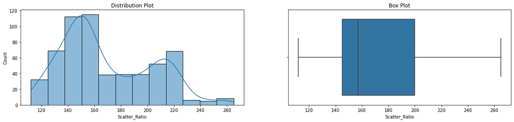

```python
fig,(ax1,ax2) = plt.subplots(nrows=1,ncols=2)
fig.set_size_inches(20,4)
sns.histplot(data=X_train,kde=True,x=X_train['Scatter_Ratio'],ax=ax1)
ax1.set_title("Distribution Plot")

sns.boxplot(data=X_train,x=X_train['Scatter_Ratio'],ax=ax2)
ax2.set_title("Box Plot")

plt.show()
```

No outliers

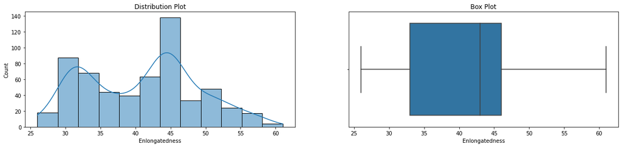

```python
fig,(ax1,ax2) = plt.subplots(nrows=1,ncols=2)
fig.set_size_inches(20,4)
sns.histplot(data=X_train,kde=True,x=X_train['Enlongatedness'],ax=ax1)
ax1.set_title("Distribution Plot")

sns.boxplot(data=X_train,x=X_train['Enlongatedness'],ax=ax2)
ax2.set_title("Box Plot")

plt.show()
```

No outliers

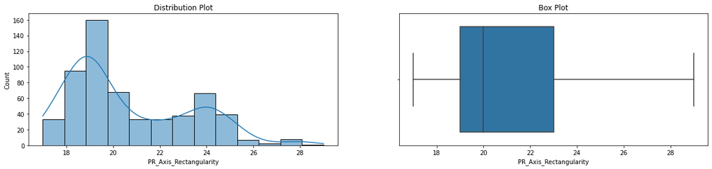

```python
fig,(ax1,ax2) = plt.subplots(nrows=1,ncols=2)
fig.set_size_inches(20,4)
sns.histplot(data=X_train,kde=True,x=X_train['PR_Axis_Rectangularity'],ax=ax1)
ax1.set_title("Distribution Plot")

sns.boxplot(data=X_train,x=X_train['PR_Axis_Rectangularity'],ax=ax2)
ax2.set_title("Box Plot")

plt.show()
```

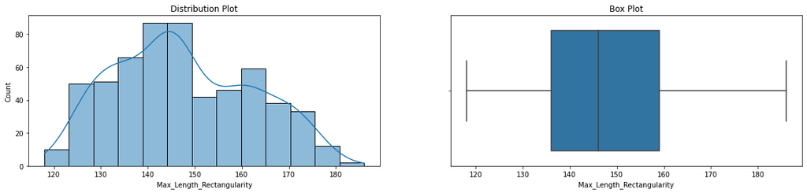

```python
fig,(ax1,ax2) = plt.subplots(nrows=1,ncols=2)
fig.set_size_inches(20,4)
sns.histplot(data=X_train,kde=True,x=X_train['Max_Length_Rectangularity'],ax=ax1)
ax1.set_title("Distribution Plot")

sns.boxplot(data=X_train,x=X_train['Max_Length_Rectangularity'],ax=ax2)
ax2.set_title("Box Plot")

plt.show()
```

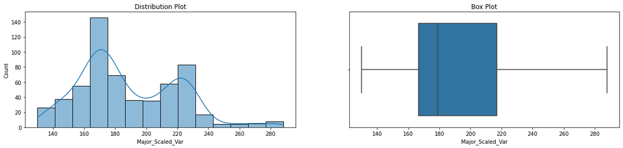

```python
fig,(ax1,ax2) = plt.subplots(nrows=1,ncols=2)
fig.set_size_inches(20,4)
sns.histplot(data=X_train,kde=True,x=X_train['Major_Scaled_Var'],ax=ax1)
ax1.set_title("Distribution Plot")

sns.boxplot(data=X_train,x=X_train['Major_Scaled_Var'],ax=ax2)
ax2.set_title("Box Plot")

plt.show()
```

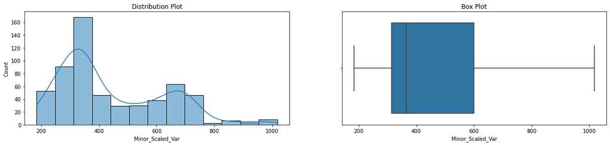

```python
fig,(ax1,ax2) = plt.subplots(nrows=1,ncols=2)
fig.set_size_inches(20,4)
sns.histplot(data=X_train,kde=True,x=X_train['Minor_Scaled_Var'],ax=ax1)
ax1.set_title("Distribution Plot")

sns.boxplot(data=X_train,x=X_train['Minor_Scaled_Var'],ax=ax2)
ax2.set_title("Box Plot")

plt.show()
```

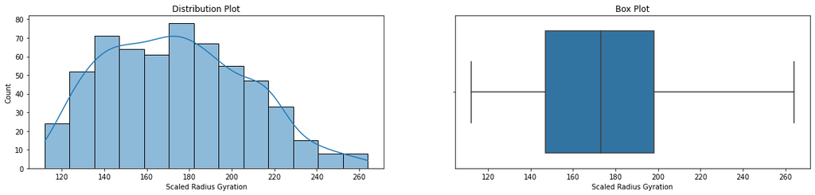

```python
fig,(ax1,ax2) = plt.subplots(nrows=1,ncols=2)
fig.set_size_inches(20,4)
sns.histplot(data=X_train,kde=True,x=X_train['Scaled Radius Gyration'],ax=ax1)
ax1.set_title("Distribution Plot")

sns.boxplot(data=X_train,x=X_train['Scaled Radius Gyration'],ax=ax2)
ax2.set_title("Box Plot")

plt.show()
```

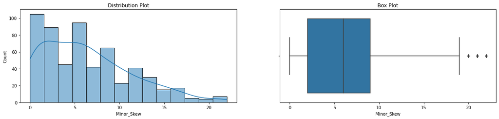

```python
fig,(ax1,ax2) = plt.subplots(nrows=1,ncols=2)
fig.set_size_inches(20,4)
sns.histplot(data=X_train,kde=True,x=X_train['Minor_Skew'],ax=ax1)
ax1.set_title("Distribution Plot")

sns.boxplot(data=X_train,x=X_train['Minor_Skew'],ax=ax2)
ax2.set_title("Box Plot")

plt.show()
```

There are outliers needed to be handled.

```python
handleOutlier(X_train['Minor_Skew'])
```

```
25th Quantile value:  2.0
Outlier low Count = 0
List of Low outliers:

Series([], Name: Minor_Skew, dtype: int32)
75th Quantile value:  9.0
Outlier High Count =  9
List of High outliers:

346    21
623    22
113    21
797    21
190    20
123    22
516    22
400    21
44     20
Name: Minor_Skew, dtype: int32
```

```python
X_train.loc[[346,623,113,797,190,123,516,400,44]]
```

|  | Compactness | Circularity | Dist_Circ | Radius_Ratio | PR_Axis_Ratio | Max_Length_Ratio | Scatter_Ratio | Enlongatedness | PR_Axis_Rectangularity | Max_Length_Rectangularity | Major_Scaled_Var | Minor_Scaled_Var | Scaled Radius Gyration | Major_Skew | Minor_Skew | Minor_Kurtosis | Major_Kurtosis | Hollow_Ratio | Vehicle_Type |
| --- | --- | --- | --- | --- | --- | --- | --- | --- | --- | --- | --- | --- | --- | --- | --- | --- | --- | --- | --- |
| 346 | 117 | 52 | 110 | 228 | 65 | 12 | 212 | 31 | 24 | 163 | 228 | 668 | 220 | 66 | 21 | 25 | 194 | 205 | 2 |
| 623 | 106 | 52 | 108 | 207 | 64 | 12 | 221 | 31 | 25 | 168 | 229 | 709 | 200 | 73 | 22 | 38 | 190 | 205 | 2 |
| 113 | 88 | 35 | 50 | 121 | 58 | 5 | 114 | 59 | 17 | 122 | 132 | 192 | 138 | 74 | 21 | 4 | 182 | 187 | 1 |
| 797 | 111 | 53 | 108 | 211 | 61 | 11 | 207 | 32 | 23 | 167 | 217 | 636 | 216 | 64 | 21 | 2 | 196 | 205 | 2 |
| 190 | 97 | 48 | 94 | 198 | 63 | 9 | 181 | 36 | 21 | 155 | 200 | 494 | 189 | 64 | 20 | 11 | 199 | 203 | 1 |
| 123 | 90 | 36 | 57 | 130 | 57 | 6 | 121 | 56 | 17 | 127 | 137 | 216 | 132 | 68 | 22 | 23 | 190 | 195 | 2 |
| 516 | 92 | 42 | 75 | 172 | 60 | 8 | 147 | 45 | 19 | 142 | 174 | 322 | 160 | 62 | 22 | 10 | 206 | 211 | 1 |
| 400 | 107 | 53 | 108 | 213 | 64 | 12 | 206 | 32 | 23 | 163 | 216 | 627 | 202 | 65 | 21 | 22 | 194 | 205 | 2 |
| 44 | 119 | 54 | 106 | 220 | 65 | 12 | 213 | 31 | 24 | 167 | 223 | 675 | 232 | 66 | 20 | 1 | 192 | 202 | 2 |

```python
# checking saab
X_train[X_train['Vehicle_Type']==2]['Minor_Skew'].sort_values( ascending=False).head(8)
```

```
623    22
123    22
400    21
346    21
797    21
44     20
196    19
689    18
Name: Minor_Skew, dtype: int32
```

```python
# checking opel
X_train[X_train['Vehicle_Type']==1]['Minor_Skew'].sort_values( ascending=False).head(8)
```

```
516    22
113    21
190    20
65     18
161    17
811    16
349    16
112    16
Name: Minor_Skew, dtype: int32
```

Outliers in both types are not much different from the max value. We will keep them.

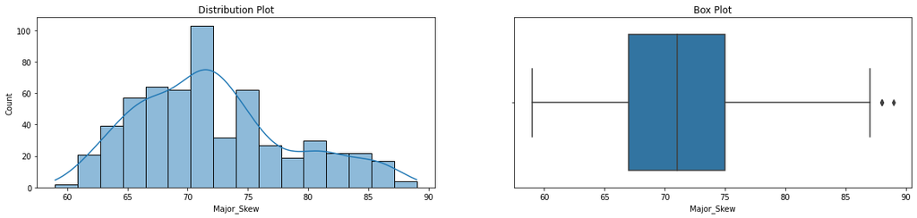

```python
fig,(ax1,ax2) = plt.subplots(nrows=1,ncols=2)
fig.set_size_inches(20,4)
sns.histplot(data=X_train,kde=True,x=X_train['Major_Skew'],ax=ax1)
ax1.set_title("Distribution Plot")

sns.boxplot(data=X_train,x=X_train['Major_Skew'],ax=ax2)
ax2.set_title("Box Plot")

plt.show()
```

```python
handleOutlier(X_train['Major_Skew'])
```

```
25th Quantile value:  67.0
Outlier low Count = 0
List of Low outliers:

Series([], Name: Major_Skew, dtype: int32)
75th Quantile value:  75.0
Outlier High Count =  4
List of High outliers:

498    88
79     88
230    89
47     88
Name: Major_Skew, dtype: int32
```

```python
X_train.loc[[498,79,230,47]]
```

|  | Compactness | Circularity | Dist_Circ | Radius_Ratio | PR_Axis_Ratio | Max_Length_Ratio | Scatter_Ratio | Enlongatedness | PR_Axis_Rectangularity | Max_Length_Rectangularity | Major_Scaled_Var | Minor_Scaled_Var | Scaled Radius Gyration | Major_Skew | Minor_Skew | Minor_Kurtosis | Major_Kurtosis | Hollow_Ratio | Vehicle_Type |
| --- | --- | --- | --- | --- | --- | --- | --- | --- | --- | --- | --- | --- | --- | --- | --- | --- | --- | --- | --- |
| 498 | 88 | 36 | 53 | 113 | 57 | 3 | 118 | 57 | 17 | 128 | 137 | 204 | 136 | 88 | 7 | 14 | 180 | 183 | 3 |
| 79 | 89 | 44 | 68 | 113 | 50 | 7 | 150 | 45 | 19 | 147 | 171 | 328 | 189 | 88 | 6 | 5 | 179 | 182 | 0 |
| 230 | 85 | 35 | 47 | 110 | 55 | 3 | 117 | 57 | 17 | 122 | 136 | 203 | 139 | 89 | 5 | 9 | 180 | 184 | 3 |
| 47 | 85 | 42 | 66 | 122 | 54 | 6 | 148 | 46 | 19 | 141 | 172 | 317 | 174 | 88 | 6 | 14 | 180 | 182 | 0 |

```python
# checking van
X_train[X_train['Vehicle_Type']==3]['Major_Skew'].sort_values( ascending=False).head(8)
```

```
230    89
498    88
734    87
795    86
420    86
41     86
617    85
546    85
Name: Major_Skew, dtype: int32
```

```python
# checking bus
X_train[X_train['Vehicle_Type']==0]['Major_Skew'].sort_values( ascending=False).head(8)
```

```
47     88
79     88
396    87
568    87
479    87
790    87
510    86
141    86
Name: Major_Skew, dtype: int32
```

Outliers in both types are not much different from the max value. We will keep them.

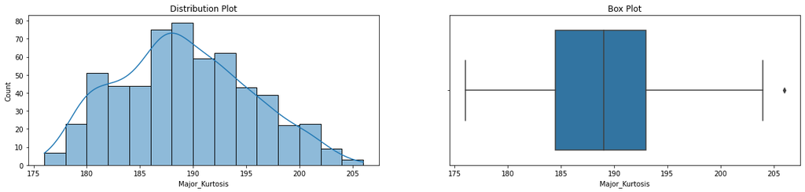

```python
fig,(ax1,ax2) = plt.subplots(nrows=1,ncols=2)
fig.set_size_inches(20,4)
sns.histplot(data=X_train,kde=True,x=X_train['Major_Kurtosis'],ax=ax1)
ax1.set_title("Distribution Plot")

sns.boxplot(data=X_train,x=X_train['Major_Kurtosis'],ax=ax2)
ax2.set_title("Box Plot")

plt.show()
```

```python
handleOutlier(X_train['Major_Kurtosis'])
```

```
25th Quantile value:  184.5
Outlier low Count = 0
List of Low outliers:

Series([], Name: Major_Kurtosis, dtype: int32)
75th Quantile value:  193.0
Outlier High Count =  1
List of High outliers:

516    206
Name: Major_Kurtosis, dtype: int32
```

```python
X_train.loc[[516]]
```

|  | Compactness | Circularity | Dist_Circ | Radius_Ratio | PR_Axis_Ratio | Max_Length_Ratio | Scatter_Ratio | Enlongatedness | PR_Axis_Rectangularity | Max_Length_Rectangularity | Major_Scaled_Var | Minor_Scaled_Var | Scaled Radius Gyration | Major_Skew | Minor_Skew | Minor_Kurtosis | Major_Kurtosis | Hollow_Ratio | Vehicle_Type |
| --- | --- | --- | --- | --- | --- | --- | --- | --- | --- | --- | --- | --- | --- | --- | --- | --- | --- | --- | --- |
| 516 | 92 | 42 | 75 | 172 | 60 | 8 | 147 | 45 | 19 | 142 | 174 | 322 | 160 | 62 | 22 | 10 | 206 | 211 | 1 |

```python
# checking the row
X_train[X_train['Vehicle_Type']==1]['Major_Kurtosis'].sort_values( ascending=False).head(8)
```

```
516    206
615    204
152    203
349    203
840    201
210    201
578    200
190    199
Name: Major_Kurtosis, dtype: int32
```

Just a slightly change. We will keep it.

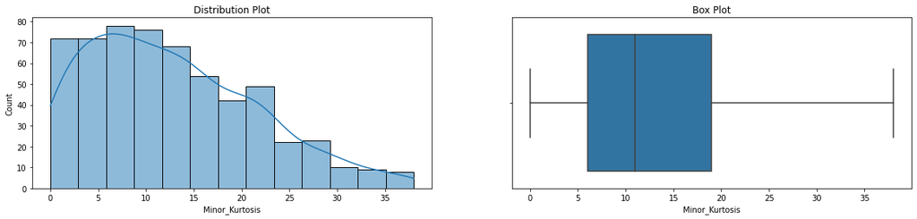

```python
fig,(ax1,ax2) = plt.subplots(nrows=1,ncols=2)
fig.set_size_inches(20,4)
sns.histplot(data=X_train,kde=True,x=X_train['Minor_Kurtosis'],ax=ax1)
ax1.set_title("Distribution Plot")

sns.boxplot(data=X_train,x=X_train['Minor_Kurtosis'],ax=ax2)
ax2.set_title("Box Plot")

plt.show()
```

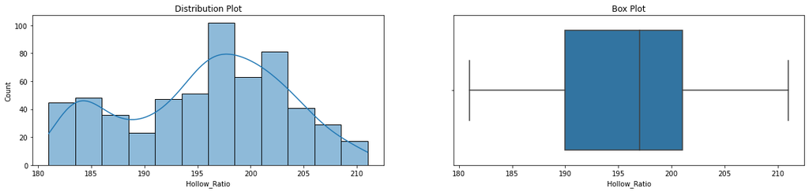

```python
fig,(ax1,ax2) = plt.subplots(nrows=1,ncols=2)
fig.set_size_inches(20,4)
sns.histplot(data=X_train,kde=True,x=X_train['Hollow_Ratio'],ax=ax1)
ax1.set_title("Distribution Plot")

sns.boxplot(data=X_train,x=X_train['Hollow_Ratio'],ax=ax2)
ax2.set_title("Box Plot")

plt.show()
```

No outliers!

```python
X_train.head()
```

|  | Compactness | Circularity | Dist_Circ | Radius_Ratio | PR_Axis_Ratio | Max_Length_Ratio | Scatter_Ratio | Enlongatedness | PR_Axis_Rectangularity | Max_Length_Rectangularity | Major_Scaled_Var | Minor_Scaled_Var | Scaled Radius Gyration | Major_Skew | Minor_Skew | Minor_Kurtosis | Major_Kurtosis | Hollow_Ratio | Vehicle_Type |
| --- | --- | --- | --- | --- | --- | --- | --- | --- | --- | --- | --- | --- | --- | --- | --- | --- | --- | --- | --- |
| 367 | 82 | 37 | 59 | 134 | 63 | 7 | 135 | 51 | 18 | 128 | 151 | 264 | 143 | 82 | 11 | 24 | 179 | 185 | 2 |
| 642 | 95 | 46 | 104 | 208 | 66 | 9 | 191 | 35 | 22 | 148 | 210 | 543 | 169 | 68 | 0 | 28 | 190 | 200 | 2 |
| 707 | 92 | 35 | 58 | 136 | 58 | 6 | 122 | 55 | 17 | 132 | 142 | 222 | 116 | 64 | 6 | 17 | 197 | 203 | 3 |
| 2 | 104 | 50 | 106 | 209 | 66 | 10 | 207 | 32 | 23 | 158 | 223 | 635 | 220 | 73 | 14 | 9 | 188 | 196 | 2 |
| 229 | 86 | 41 | 64 | 148 | 61 | 5 | 150 | 45 | 19 | 138 | 165 | 333 | 173 | 80 | 5 | 8 | 182 | 185 | 2 |

**PCA and Dimentionality Reduction**

```python
y_to_train=X_train['Vehicle_Type']
X_to_train=X_train.drop(labels='Vehicle_Type', axis=1)
y_to_test=X_test['Vehicle_Type']
X_to_test=X_test.drop(labels='Vehicle_Type', axis=1)
```

```python
from sklearn.preprocessing import StandardScaler

scaler = StandardScaler()
```

```python
scaler.fit(X_to_train)
```

```
StandardScaler()
```

```python
X_train_scaled = scaler.transform(X_to_train)
X_test_scaled= scaler.transform(X_to_test)
```

```python
# Covariance Matrix
cov_matrix = np.cov(X_train_scaled.T)

print('Covariance Matrix \n%s', cov_matrix)
```

```
Covariance Matrix
%s [[ 1.00171821  0.70896656  0.80098503  0.75126509  0.19942665  0.53294407
   0.82084885 -0.7930435   0.82298779  0.70130525  0.80070072  0.82664918
   0.60252261 -0.25276219  0.20383352  0.12200785  0.28996599  0.35472527]
 [ 0.70896656  1.00171821  0.8096198   0.67228118  0.20947378  0.57582912
   0.86947604 -0.83605762  0.8677792   0.97122418  0.83228035  0.86263829
   0.93988615  0.04290716  0.13866773 -0.01231304 -0.09540489  0.0582611 ]
 [ 0.80098503  0.8096198   1.00171821  0.82826502  0.25837893  0.69838484
   0.91408048 -0.92061118  0.9005146   0.78809572  0.89119317  0.89512289
   0.71644211 -0.26579551  0.11070542  0.24221805  0.15849957  0.34653219]
 [ 0.75126509  0.67228118  0.82826502  1.00171821  0.6728968   0.51367661
   0.80320047 -0.85773386  0.77386148  0.61758896  0.79898543  0.78960915
   0.57553943 -0.41503744  0.04781468  0.1843635   0.42569695  0.51732482]
 [ 0.19942665  0.20947378  0.25837893  0.6728968   1.00171821  0.16308321
   0.20973097 -0.31624755  0.17132922  0.16468628  0.21902847  0.1944352
   0.15382736 -0.34385425 -0.06919546 -0.02104821  0.42283111  0.44300413]
 [ 0.53294407  0.57582912  0.69838484  0.51367661  0.16308321  1.00171821
   0.5204018  -0.53617041  0.5145103   0.6545969   0.44036088  0.48235118
   0.42299205 -0.3864339   0.10404603  0.12271502  0.11817695  0.44504733]
 [ 0.82084885  0.86947604  0.91408048  0.80320047  0.20973097  0.5204018
   1.00171821 -0.97447108  0.99366925  0.8256287   0.98442018  0.99804638
   0.81162842 -0.0145616   0.05983887  0.20059643  0.01236376  0.1305611 ]
 [-0.7930435  -0.83605762 -0.92061118 -0.85773386 -0.31624755 -0.53617041
  -0.97447108  1.00171821 -0.95004477 -0.78895762 -0.96837092 -0.9569303
  -0.77448815  0.11153217 -0.03114745 -0.17588287 -0.12478412 -0.23236216]
 [ 0.82298779  0.8677792   0.9005146   0.77386148  0.17132922  0.5145103
   0.99366925 -0.95004477  1.00171821  0.82839879  0.97250307  0.99459871
   0.81020035  0.00520459  0.06762294  0.20051973 -0.01643956  0.10620893]
 [ 0.70130525  0.97122418  0.78809572  0.61758896  0.16468628  0.6545969
   0.8256287  -0.78895762  0.82839879  1.00171821  0.7767574   0.81518568
   0.87782176  0.02031962  0.12898888 -0.00727704 -0.08748606  0.0909597 ]
 [ 0.80070072  0.83228035  0.89119317  0.79898543  0.21902847  0.44036088
   0.98442018 -0.96837092  0.97250307  0.7767574   1.00171821  0.98284821
   0.8016038   0.00834329  0.03225907  0.19249056  0.02957243  0.10283881]
 [ 0.82664918  0.86263829  0.89512289  0.78960915  0.1944352   0.48235118
   0.99804638 -0.9569303   0.99459871  0.81518568  0.98284821  1.00171821
   0.80908312  0.00190985  0.06430372  0.19304623  0.0094033   0.11245008]
 [ 0.60252261  0.93988615  0.71644211  0.57553943  0.15382736  0.42299205
   0.81162842 -0.77448815  0.81020035  0.87782176  0.8016038   0.80908312
   1.00171821  0.1907325   0.15923356 -0.05131808 -0.21193718 -0.09783518]
 [-0.25276219  0.04290716 -0.26579551 -0.41503744 -0.34385425 -0.3864339
  -0.0145616   0.11153217  0.00520459  0.02031962  0.00834329  0.00190985
   0.1907325   1.00171821 -0.11341747 -0.11539675 -0.85027963 -0.92069976]
 [ 0.20383352  0.13866773  0.11070542  0.04781468 -0.06919546  0.10404603
   0.05983887 -0.03114745  0.06762294  0.12898888  0.03225907  0.06430372
   0.15923356 -0.11341747  1.00171821 -0.06114103  0.11846127  0.09593123]
 [ 0.12200785 -0.01231304  0.24221805  0.1843635  -0.02104821  0.12271502
   0.20059643 -0.17588287  0.20051973 -0.00727704  0.19249056  0.19304623
  -0.05131808 -0.11539675 -0.06114103  1.00171821  0.06226837  0.17967274]
 [ 0.28996599 -0.09540489  0.15849957  0.42569695  0.42283111  0.11817695
   0.01236376 -0.12478412 -0.01643956 -0.08748606  0.02957243  0.0094033
  -0.21193718 -0.85027963  0.11846127  0.06226837  1.00171821  0.89396372]
 [ 0.35472527  0.0582611   0.34653219  0.51732482  0.44300413  0.44504733
   0.1305611  -0.23236216  0.10620893  0.0909597   0.10283881  0.11245008
  -0.09783518 -0.92069976  0.09593123  0.17967274  0.89396372  1.00171821]]
```

```python
eig_vals, eig_vecs = np.linalg.eig(cov_matrix)
print('Eigen Vectors \n%s', eig_vecs)
print('\n Eigen Values \n%s', eig_vals)
```

```
Eigen Vectors
%s [[-2.72032543e-01 -7.13975770e-02  8.10998453e-02  1.14287726e-01
  -1.26083066e-01 -2.90465839e-01  2.40215420e-01 -7.59358822e-01
   3.13957522e-01 -1.69247885e-01 -6.24343863e-02  1.24788858e-02
  -1.63624612e-01  9.23531671e-02  1.51314330e-03  2.64824637e-03
   8.05439851e-03 -4.57779100e-03]
 [-2.87330182e-01  1.32147219e-01  1.71534028e-01 -8.72357688e-02
   1.19925678e-01  1.01034895e-01 -3.75827722e-01 -8.69451413e-02
   5.89790729e-02  2.03360197e-01 -5.30706021e-02 -2.32211069e-02
  -1.30317657e-01 -2.13615583e-01  1.03716340e-02  1.89906754e-01
   6.26174789e-01 -3.87914157e-01]
 [-3.00680561e-01 -4.46464997e-02 -3.03449001e-02  1.21018689e-01
   8.74447253e-02  1.44248920e-02  1.72274073e-01  2.93029105e-01
   2.14678864e-01 -7.45203872e-02 -7.40688062e-01  3.48042750e-01
   1.69838776e-01 -2.98309432e-02 -1.05914862e-02 -3.65164028e-02
  -5.77228687e-02 -1.12813870e-01]
 [-2.74637847e-01 -1.93887587e-01 -1.24330509e-01 -2.08250222e-01
  -1.43620841e-01  1.27917877e-01  1.60500979e-01  5.01333433e-02
   1.73641948e-01  4.89797042e-02  1.02056389e-01 -2.18162106e-01
  -8.98417825e-03 -7.85540334e-01 -2.67088122e-02  6.24511261e-03
  -1.84286258e-01  1.43047942e-01]
 [-1.01023410e-01 -2.64054073e-01 -1.28369532e-01 -6.09111371e-01
  -1.60203333e-01  5.53408429e-01  1.41327648e-01 -1.57566806e-01
  -4.05125708e-03  3.60196958e-02 -3.23150511e-02  9.79500720e-02
   5.96468342e-02  3.65893180e-01  1.76608242e-02 -3.52595503e-03
   6.17359828e-02 -4.82076343e-02]
 [-2.01314406e-01 -1.19900702e-01  1.92592240e-01  2.15181226e-01
   6.39755099e-01  2.82562936e-01  3.89841108e-01 -3.90156904e-02
  -1.96533189e-01 -2.31874415e-01  1.81774662e-01 -2.23263289e-01
   1.81780993e-01  1.50576270e-02 -1.12820074e-02  1.73685128e-03
   6.60539459e-02 -7.76584794e-02]
 [-3.07942075e-01  8.00651666e-02 -9.67669341e-02  3.11848361e-02
  -8.10841265e-02 -9.94066273e-02  8.33974038e-02  1.03568627e-01
  -1.16818527e-01  1.13820645e-01  1.74047558e-01  5.07884513e-02
  -3.71374571e-02  5.54274587e-02  7.91610661e-01 -3.82679865e-01
  -7.81278646e-03 -1.31185121e-01]
 [ 3.05909385e-01 -1.50349239e-02  1.09659517e-01  4.31820217e-02
   6.74241976e-02  8.17045940e-02 -9.07198006e-02 -2.53940432e-01
   2.61946462e-01  1.18851044e-01  9.93391212e-02  3.01924979e-01
   6.90725843e-01 -1.93086727e-01  2.20553016e-01 -5.98810617e-02
```

[output cut: 43 more lines]

```
  -3.74924711e-01 -1.65247393e-01 -1.88888650e-01 -3.18660735e-01
   3.99616706e-01 -5.15052326e-03  2.60167440e-02 -5.58835616e-03
  -5.10989952e-02 -2.71647493e-01]
 [-8.93653822e-02 -5.04853372e-01  4.49685791e-02  7.28513042e-02
   1.15617166e-01 -5.02835025e-02 -1.81077953e-01  6.02544913e-03
  -2.62555853e-01 -1.44516257e-01  1.72921720e-01  6.23797658e-01
  -2.97977772e-01 -1.26894266e-01 -3.45767349e-03  2.86004097e-02
   8.73553259e-02  2.42665122e-01]]

 Eigen Values
%s [9.97432193e+00 3.37729049e+00 1.22083392e+00 1.11788876e+00
 8.35006256e-01 6.30550052e-01 3.07179858e-01 2.19004393e-01
 1.02431245e-01 7.31324280e-02 5.48846957e-02 4.18677794e-02
 2.55573194e-02 2.04245824e-02 3.24110846e-04 5.70832649e-03
 1.04972990e-02 1.40243959e-02]
```

```python
print("Eigen Values:")
pd.DataFrame(eig_vals).transpose()
```

```
Eigen Values:
```

|  | 0 | 1 | 2 | 3 | 4 | 5 | 6 | 7 | 8 | 9 | 10 | 11 | 12 | 13 | 14 | 15 | 16 | 17 |
| --- | --- | --- | --- | --- | --- | --- | --- | --- | --- | --- | --- | --- | --- | --- | --- | --- | --- | --- |
| 0 | 9.974322 | 3.37729 | 1.220834 | 1.117889 | 0.835006 | 0.63055 | 0.30718 | 0.219004 | 0.102431 | 0.073132 | 0.054885 | 0.041868 | 0.025557 | 0.020425 | 0.000324 | 0.005708 | 0.010497 | 0.014024 |

```python
eig_vals[0] / sum(eig_vals)
```

```
0.5531785173594634
```

The first vector accounts for 55% of the variance

```python
tot = sum(eig_vals)
var_exp = [( i /tot ) * 100 for i in sorted(eig_vals, reverse=True)]
cum_var_exp = np.cumsum(var_exp)   # array of size =  as many PC dimensions
print("Cumulative Variance Explained", cum_var_exp)
```

```
Cumulative Variance Explained [ 55.31785174  74.04839364  80.81917065  87.01901109  91.64997775
  95.14702492  96.8506525   98.06525662  98.633343    99.03893737
  99.34332934  99.57552914  99.71727071  99.83054598  99.90832565
  99.96654394  99.99820247 100.        ]
```

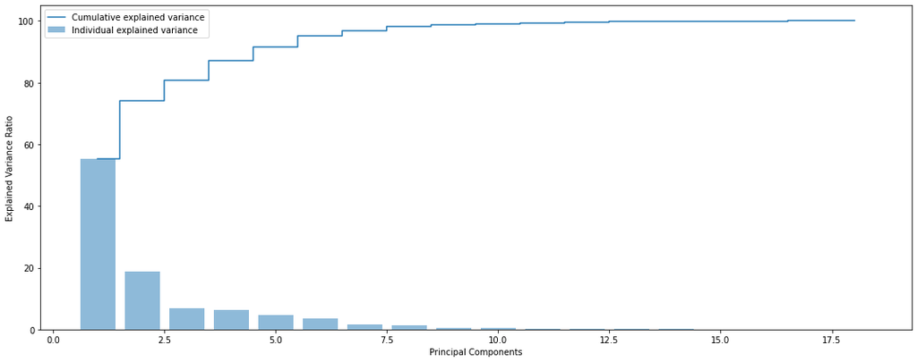

```python
plt.figure(figsize=(15 , 6))
plt.bar(range(1, eig_vals.size + 1), var_exp, alpha = 0.5, align = 'center', label = 'Individual explained variance')
plt.step(range(1, eig_vals.size + 1), cum_var_exp, where='mid', label = 'Cumulative explained variance')
plt.ylabel('Explained Variance Ratio')
plt.xlabel('Principal Components')
plt.legend(loc = 'best')
plt.tight_layout()
plt.show()
```

```python
# Make a set of (eigenvalue, eigenvector) pairs
eig_pairs = [(eig_vals[index], eig_vecs[index]) for index in range(len(eig_vals))]

# Sort the (eigenvalue, eigenvector) pairs from highest to lowest with respect to eigenvalue by default take first field for sorting
eig_pairs.sort(reverse=True)


# Note: always form pair of eigen vector and values  first before sorting...

# Extract the descending ordered eigenvalues and eigenvectors
eigvalues_sorted = [eig_pairs[index][0] for index in range(len(eig_vals))]
eigvectors_sorted = [eig_pairs[index][1] for index in range(len(eig_vals))]
```

```python
#Dimesionality reduction

P_reduce = np.array(eigvectors_sorted[0:8]).transpose()   # Selecting first 8 eigen vector out if 18

Proj_train_data = np.dot(X_train_scaled,P_reduce)   # projecting training data onto the eight eigen vectors

Proj_test_data = np.dot(X_test_scaled,P_reduce)    # projecting test data onto the eight eigen vectors
```

```python
#Check shapes of train and test new feature and target set after PCA
Proj_train_data.shape,y_to_train.shape,Proj_test_data.shape,y_to_test.shape
```

```
((583, 8), (583,), (254, 8), (254,))
```

First, we will train using a neural network.

```python
from sklearn.neural_network import MLPClassifier

mlp = MLPClassifier(max_iter=1000, activation='relu',hidden_layer_sizes=(1024, 512, 256))
mlp.fit(Proj_train_data,y_to_train)
```

```
MLPClassifier(hidden_layer_sizes=(1024, 512, 256), max_iter=1000)
```

```python
predictions = mlp.predict(Proj_test_data)
```

```python
from sklearn.metrics import classification_report, confusion_matrix

print(confusion_matrix(y_to_test,predictions))
print(classification_report(y_to_test,predictions))
```

```
[[63  1  0  2]
 [ 2 34 17  2]
 [ 3 39 30  0]
 [ 1  4  1 55]]
              precision    recall  f1-score   support

           0       0.91      0.95      0.93        66
           1       0.44      0.62      0.51        55
           2       0.62      0.42      0.50        72
           3       0.93      0.90      0.92        61

    accuracy                           0.72       254
   macro avg       0.73      0.72      0.72       254
weighted avg       0.73      0.72      0.72       254
```

```python
mlp2 = MLPClassifier(max_iter=3000, activation='logistic', hidden_layer_sizes=(1000, 900))
mlp2.fit(Proj_train_data,y_to_train)

predictions2 = mlp2.predict(Proj_test_data)

print(confusion_matrix(y_to_test,predictions2))
print(classification_report(y_to_test,predictions2))
```

```
[[62  1  1  2]
 [ 2 28 24  1]
 [ 5 25 40  2]
 [ 3  4  2 52]]
              precision    recall  f1-score   support

           0       0.86      0.94      0.90        66
           1       0.48      0.51      0.50        55
           2       0.60      0.56      0.58        72
           3       0.91      0.85      0.88        61

    accuracy                           0.72       254
   macro avg       0.71      0.71      0.71       254
weighted avg       0.72      0.72      0.72       254
```

```python
# Experiment with gridSearch
param_grid = {'solver': ['lbfgs', 'sgd', 'adam'], 'activation': ['identity', 'logistic', 'tanh', 'relu'], 'learning_rate': ['constant', 'invscaling', 'adaptive']}
```

```python
from sklearn.model_selection import GridSearchCV

grid = GridSearchCV(MLPClassifier(max_iter=1000, hidden_layer_sizes=(1024, 512, 256)),param_grid,refit=True,verbose=3)
```

```python
grid.fit(Proj_train_data,y_to_train)
```

```
Fitting 5 folds for each of 36 candidates, totalling 180 fits
[CV 1/5] END activation=identity, learning_rate=constant, solver=lbfgs;, score=0.701 total time=  21.4s
[CV 2/5] END activation=identity, learning_rate=constant, solver=lbfgs;, score=0.632 total time=  26.2s
[CV 3/5] END activation=identity, learning_rate=constant, solver=lbfgs;, score=0.624 total time=  24.9s
[CV 4/5] END activation=identity, learning_rate=constant, solver=lbfgs;, score=0.681 total time=  26.6s
[CV 5/5] END activation=identity, learning_rate=constant, solver=lbfgs;, score=0.638 total time=  21.8s
[CV 1/5] END activation=identity, learning_rate=constant, solver=sgd;, score=0.692 total time= 1.6min
[CV 2/5] END activation=identity, learning_rate=constant, solver=sgd;, score=0.624 total time= 1.3min
[CV 3/5] END activation=identity, learning_rate=constant, solver=sgd;, score=0.684 total time= 1.3min
[CV 4/5] END activation=identity, learning_rate=constant, solver=sgd;, score=0.681 total time= 1.2min
[CV 5/5] END activation=identity, learning_rate=constant, solver=sgd;, score=0.664 total time= 1.3min
[CV 1/5] END activation=identity, learning_rate=constant, solver=adam;, score=0.701 total time=   8.6s
[CV 2/5] END activation=identity, learning_rate=constant, solver=adam;, score=0.590 total time=   9.6s
[CV 3/5] END activation=identity, learning_rate=constant, solver=adam;, score=0.624 total time=   8.3s
[CV 4/5] END activation=identity, learning_rate=constant, solver=adam;, score=0.664 total time=   4.4s
[CV 5/5] END activation=identity, learning_rate=constant, solver=adam;, score=0.629 total time=   7.8s
[CV 1/5] END activation=identity, learning_rate=invscaling, solver=lbfgs;, score=0.701 total time=  11.2s
[CV 2/5] END activation=identity, learning_rate=invscaling, solver=lbfgs;, score=0.632 total time=  11.2s
[CV 3/5] END activation=identity, learning_rate=invscaling, solver=lbfgs;, score=0.632 total time=  11.4s
[CV 4/5] END activation=identity, learning_rate=invscaling, solver=lbfgs;, score=0.681 total time=  11.5s
[CV 5/5] END activation=identity, learning_rate=invscaling, solver=lbfgs;, score=0.638 total time=  11.5s
[CV 1/5] END activation=identity, learning_rate=invscaling, solver=sgd;, score=0.368 total time=  48.2s
[CV 2/5] END activation=identity, learning_rate=invscaling, solver=sgd;, score=0.359 total time=  50.6s
[CV 3/5] END activation=identity, learning_rate=invscaling, solver=sgd;, score=0.547 total time=  36.5s
[CV 4/5] END activation=identity, learning_rate=invscaling, solver=sgd;, score=0.440 total time=  39.4s
[CV 5/5] END activation=identity, learning_rate=invscaling, solver=sgd;, score=0.466 total time=  47.7s
[CV 1/5] END activation=identity, learning_rate=invscaling, solver=adam;, score=0.701 total time=   6.9s
[CV 2/5] END activation=identity, learning_rate=invscaling, solver=adam;, score=0.675 total time=   6.9s
[CV 3/5] END activation=identity, learning_rate=invscaling, solver=adam;, score=0.641 total time=  12.0s
[CV 4/5] END activation=identity, learning_rate=invscaling, solver=adam;, score=0.690 total time=  10.9s
[CV 5/5] END activation=identity, learning_rate=invscaling, solver=adam;, score=0.603 total time=  11.4s
[CV 1/5] END activation=identity, learning_rate=adaptive, solver=lbfgs;, score=0.701 total time=  11.9s
[CV 2/5] END activation=identity, learning_rate=adaptive, solver=lbfgs;, score=0.632 total time=  15.0s
[CV 3/5] END activation=identity, learning_rate=adaptive, solver=lbfgs;, score=0.624 total time=  15.3s
[CV 4/5] END activation=identity, learning_rate=adaptive, solver=lbfgs;, score=0.681 total time=  13.2s
[CV 5/5] END activation=identity, learning_rate=adaptive, solver=lbfgs;, score=0.638 total time=  12.4s
[CV 1/5] END activation=identity, learning_rate=adaptive, solver=sgd;, score=0.701 total time= 1.5min
[CV 2/5] END activation=identity, learning_rate=adaptive, solver=sgd;, score=0.615 total time= 1.5min
[CV 3/5] END activation=identity, learning_rate=adaptive, solver=sgd;, score=0.684 total time= 1.4min
[CV 4/5] END activation=identity, learning_rate=adaptive, solver=sgd;, score=0.672 total time= 1.5min
```

[output cut: 41 more lines]

```
[CV 1/5] END activation=logistic, learning_rate=adaptive, solver=sgd;, score=0.265 total time=  21.0s
[CV 2/5] END activation=logistic, learning_rate=adaptive, solver=sgd;, score=0.274 total time=  20.5s
[CV 3/5] END activation=logistic, learning_rate=adaptive, solver=sgd;, score=0.274 total time=  19.0s
[CV 4/5] END activation=logistic, learning_rate=adaptive, solver=sgd;, score=0.267 total time=  19.6s
[CV 5/5] END activation=logistic, learning_rate=adaptive, solver=sgd;, score=0.267 total time=  19.2s
[CV 1/5] END activation=logistic, learning_rate=adaptive, solver=adam;, score=0.761 total time= 1.4min
[CV 2/5] END activation=logistic, learning_rate=adaptive, solver=adam;, score=0.744 total time= 1.4min
[CV 3/5] END activation=logistic, learning_rate=adaptive, solver=adam;, score=0.735 total time= 1.7min
[CV 4/5] END activation=logistic, learning_rate=adaptive, solver=adam;, score=0.707 total time=  56.0s
[CV 5/5] END activation=logistic, learning_rate=adaptive, solver=adam;, score=0.716 total time= 1.0min
[CV 1/5] END activation=tanh, learning_rate=constant, solver=lbfgs;, score=0.709 total time=  30.4s
[CV 2/5] END activation=tanh, learning_rate=constant, solver=lbfgs;, score=0.769 total time=  29.2s
[CV 3/5] END activation=tanh, learning_rate=constant, solver=lbfgs;, score=0.709 total time=  32.6s
[CV 4/5] END activation=tanh, learning_rate=constant, solver=lbfgs;, score=0.724 total time=  30.2s
[CV 5/5] END activation=tanh, learning_rate=constant, solver=lbfgs;, score=0.707 total time=  30.5s
```

```
[CV 1/5] END activation=tanh, learning_rate=constant, solver=sgd;, score=0.726 total time= 4.6min
```

```
[CV 2/5] END activation=tanh, learning_rate=constant, solver=sgd;, score=0.735 total time= 4.6min
```

```
[CV 3/5] END activation=tanh, learning_rate=constant, solver=sgd;, score=0.701 total time= 4.6min
```

```
[CV 4/5] END activation=tanh, learning_rate=constant, solver=sgd;, score=0.767 total time= 4.7min
```

```
[CV 5/5] END activation=tanh, learning_rate=constant, solver=sgd;, score=0.707 total time= 4.5min
[CV 1/5] END activation=tanh, learning_rate=constant, solver=adam;, score=0.761 total time= 1.6min
[CV 2/5] END activation=tanh, learning_rate=constant, solver=adam;, score=0.795 total time= 1.8min
[CV 3/5] END activation=tanh, learning_rate=constant, solver=adam;, score=0.795 total time= 1.9min
[CV 4/5] END activation=tanh, learning_rate=constant, solver=adam;, score=0.741 total time= 1.8min
[CV 5/5] END activation=tanh, learning_rate=constant, solver=adam;, score=0.707 total time= 1.8min
[CV 1/5] END activation=tanh, learning_rate=invscaling, solver=lbfgs;, score=0.692 total time=  31.1s
[CV 2/5] END activation=tanh, learning_rate=invscaling, solver=lbfgs;, score=0.761 total time=  29.3s
[CV 3/5] END activation=tanh, learning_rate=invscaling, solver=lbfgs;, score=0.658 total time=  35.2s
[CV 4/5] END activation=tanh, learning_rate=invscaling, solver=lbfgs;, score=0.707 total time=  29.7s
[CV 5/5] END activation=tanh, learning_rate=invscaling, solver=lbfgs;, score=0.690 total time=  30.8s
[CV 1/5] END activation=tanh, learning_rate=invscaling, solver=sgd;, score=0.462 total time= 1.2min
[CV 2/5] END activation=tanh, learning_rate=invscaling, solver=sgd;, score=0.359 total time= 1.1min
[CV 3/5] END activation=tanh, learning_rate=invscaling, solver=sgd;, score=0.393 total time= 1.7min
[CV 4/5] END activation=tanh, learning_rate=invscaling, solver=sgd;, score=0.552 total time= 1.0min
[CV 5/5] END activation=tanh, learning_rate=invscaling, solver=sgd;, score=0.414 total time= 1.3min
[CV 1/5] END activation=tanh, learning_rate=invscaling, solver=adam;, score=0.761 total time= 1.8min
[CV 2/5] END activation=tanh, learning_rate=invscaling, solver=adam;, score=0.795 total time= 2.0min
[CV 3/5] END activation=tanh, learning_rate=invscaling, solver=adam;, score=0.778 total time= 1.9min
[CV 4/5] END activation=tanh, learning_rate=invscaling, solver=adam;, score=0.724 total time= 1.9min
[CV 5/5] END activation=tanh, learning_rate=invscaling, solver=adam;, score=0.741 total time= 1.6min
[CV 1/5] END activation=tanh, learning_rate=adaptive, solver=lbfgs;, score=0.752 total time=  23.9s
[CV 2/5] END activation=tanh, learning_rate=adaptive, solver=lbfgs;, score=0.692 total time=  27.7s
[CV 3/5] END activation=tanh, learning_rate=adaptive, solver=lbfgs;, score=0.709 total time=  31.0s
[CV 4/5] END activation=tanh, learning_rate=adaptive, solver=lbfgs;, score=0.750 total time=  24.8s
[CV 5/5] END activation=tanh, learning_rate=adaptive, solver=lbfgs;, score=0.741 total time=  25.1s
```

```
[CV 1/5] END activation=tanh, learning_rate=adaptive, solver=sgd;, score=0.726 total time= 4.1min
```

```
[CV 2/5] END activation=tanh, learning_rate=adaptive, solver=sgd;, score=0.744 total time= 4.5min
```

```
[CV 3/5] END activation=tanh, learning_rate=adaptive, solver=sgd;, score=0.718 total time= 3.9min
```

```
[CV 4/5] END activation=tanh, learning_rate=adaptive, solver=sgd;, score=0.767 total time= 3.3min
```

```
[CV 5/5] END activation=tanh, learning_rate=adaptive, solver=sgd;, score=0.724 total time= 3.3min
[CV 1/5] END activation=tanh, learning_rate=adaptive, solver=adam;, score=0.744 total time= 1.2min
[CV 2/5] END activation=tanh, learning_rate=adaptive, solver=adam;, score=0.778 total time= 1.2min
[CV 3/5] END activation=tanh, learning_rate=adaptive, solver=adam;, score=0.803 total time= 1.3min
[CV 4/5] END activation=tanh, learning_rate=adaptive, solver=adam;, score=0.733 total time= 1.2min
[CV 5/5] END activation=tanh, learning_rate=adaptive, solver=adam;, score=0.716 total time= 1.2min
[CV 1/5] END activation=relu, learning_rate=constant, solver=lbfgs;, score=0.701 total time=  30.8s
[CV 2/5] END activation=relu, learning_rate=constant, solver=lbfgs;, score=0.692 total time=  36.3s
[CV 3/5] END activation=relu, learning_rate=constant, solver=lbfgs;, score=0.769 total time=  38.9s
[CV 4/5] END activation=relu, learning_rate=constant, solver=lbfgs;, score=0.698 total time=  33.5s
[CV 5/5] END activation=relu, learning_rate=constant, solver=lbfgs;, score=0.724 total time=  39.5s
```

```
[CV 1/5] END activation=relu, learning_rate=constant, solver=sgd;, score=0.752 total time= 3.0min
```

```
[CV 2/5] END activation=relu, learning_rate=constant, solver=sgd;, score=0.752 total time= 3.0min
```

```
[CV 3/5] END activation=relu, learning_rate=constant, solver=sgd;, score=0.752 total time= 3.0min
```

```
[CV 4/5] END activation=relu, learning_rate=constant, solver=sgd;, score=0.776 total time= 3.1min
```

```
[CV 5/5] END activation=relu, learning_rate=constant, solver=sgd;, score=0.776 total time= 3.0min
[CV 1/5] END activation=relu, learning_rate=constant, solver=adam;, score=0.726 total time=  20.2s
[CV 2/5] END activation=relu, learning_rate=constant, solver=adam;, score=0.709 total time=  25.7s
[CV 3/5] END activation=relu, learning_rate=constant, solver=adam;, score=0.769 total time=  54.0s
[CV 4/5] END activation=relu, learning_rate=constant, solver=adam;, score=0.698 total time=  19.5s
[CV 5/5] END activation=relu, learning_rate=constant, solver=adam;, score=0.741 total time=  44.4s
[CV 1/5] END activation=relu, learning_rate=invscaling, solver=lbfgs;, score=0.752 total time=  34.9s
[CV 2/5] END activation=relu, learning_rate=invscaling, solver=lbfgs;, score=0.726 total time=  34.8s
[CV 3/5] END activation=relu, learning_rate=invscaling, solver=lbfgs;, score=0.752 total time=  33.5s
[CV 4/5] END activation=relu, learning_rate=invscaling, solver=lbfgs;, score=0.741 total time=  35.0s
[CV 5/5] END activation=relu, learning_rate=invscaling, solver=lbfgs;, score=0.733 total time=  37.4s
[CV 1/5] END activation=relu, learning_rate=invscaling, solver=sgd;, score=0.274 total time=   5.9s
[CV 2/5] END activation=relu, learning_rate=invscaling, solver=sgd;, score=0.256 total time=   5.5s
[CV 3/5] END activation=relu, learning_rate=invscaling, solver=sgd;, score=0.350 total time=   5.9s
[CV 4/5] END activation=relu, learning_rate=invscaling, solver=sgd;, score=0.310 total time=   5.3s
[CV 5/5] END activation=relu, learning_rate=invscaling, solver=sgd;, score=0.276 total time=   4.9s
[CV 1/5] END activation=relu, learning_rate=invscaling, solver=adam;, score=0.726 total time=  26.6s
[CV 2/5] END activation=relu, learning_rate=invscaling, solver=adam;, score=0.778 total time=  22.4s
[CV 3/5] END activation=relu, learning_rate=invscaling, solver=adam;, score=0.744 total time=  45.3s
[CV 4/5] END activation=relu, learning_rate=invscaling, solver=adam;, score=0.716 total time=  22.9s
[CV 5/5] END activation=relu, learning_rate=invscaling, solver=adam;, score=0.750 total time=  27.1s
[CV 1/5] END activation=relu, learning_rate=adaptive, solver=lbfgs;, score=0.761 total time=  29.4s
[CV 2/5] END activation=relu, learning_rate=adaptive, solver=lbfgs;, score=0.752 total time=  38.9s
[CV 3/5] END activation=relu, learning_rate=adaptive, solver=lbfgs;, score=0.761 total time=  35.6s
[CV 4/5] END activation=relu, learning_rate=adaptive, solver=lbfgs;, score=0.707 total time=  37.1s
[CV 5/5] END activation=relu, learning_rate=adaptive, solver=lbfgs;, score=0.733 total time=  46.8s
```

```
[CV 1/5] END activation=relu, learning_rate=adaptive, solver=sgd;, score=0.735 total time= 3.1min
```

```
[CV 2/5] END activation=relu, learning_rate=adaptive, solver=sgd;, score=0.769 total time= 3.0min
```

```
[CV 3/5] END activation=relu, learning_rate=adaptive, solver=sgd;, score=0.735 total time= 3.0min
```

```
[CV 4/5] END activation=relu, learning_rate=adaptive, solver=sgd;, score=0.784 total time= 3.1min
```

```
[CV 5/5] END activation=relu, learning_rate=adaptive, solver=sgd;, score=0.793 total time= 3.1min
[CV 1/5] END activation=relu, learning_rate=adaptive, solver=adam;, score=0.752 total time=  39.6s
[CV 2/5] END activation=relu, learning_rate=adaptive, solver=adam;, score=0.718 total time=  25.0s
[CV 3/5] END activation=relu, learning_rate=adaptive, solver=adam;, score=0.769 total time=  48.3s
[CV 4/5] END activation=relu, learning_rate=adaptive, solver=adam;, score=0.724 total time=  24.3s
[CV 5/5] END activation=relu, learning_rate=adaptive, solver=adam;, score=0.759 total time=  33.8s
```

```
GridSearchCV(estimator=MLPClassifier(hidden_layer_sizes=(1024, 512, 256),
                                     max_iter=1000),
             param_grid={'activation': ['identity', 'logistic', 'tanh', 'relu'],
                         'learning_rate': ['constant', 'invscaling',
                                           'adaptive'],
                         'solver': ['lbfgs', 'sgd', 'adam']},
             verbose=3)
```

```python
grid.best_params_
```

```
{'activation': 'relu', 'learning_rate': 'adaptive', 'solver': 'sgd'}
```

```python
grid_predictions = grid.predict(Proj_test_data)
```

```python
print(confusion_matrix(y_to_test, grid_predictions))
print(classification_report(y_to_test, grid_predictions))
```

```
[[63  1  0  2]
 [ 3 38 12  2]
 [ 4 38 30  0]
 [ 0  4  2 55]]
              precision    recall  f1-score   support

           0       0.90      0.95      0.93        66
           1       0.47      0.69      0.56        55
           2       0.68      0.42      0.52        72
           3       0.93      0.90      0.92        61

    accuracy                           0.73       254
   macro avg       0.75      0.74      0.73       254
weighted avg       0.75      0.73      0.73       254
```

Next, we'll train using KNN.

```python
from sklearn.neighbors import KNeighborsClassifier

# will append scores here for plotting later
test_scores = []
train_scores = []

# testing k values from 1-14
for i in range(1,15):
    # create a model with k=i
    knn = KNeighborsClassifier(i)
    # train the model
    knn.fit(Proj_train_data,y_to_train)

    # append scores.
    train_scores.append(knn.score(Proj_train_data,y_to_train))
    test_scores.append(knn.score(Proj_test_data,y_to_test))
```

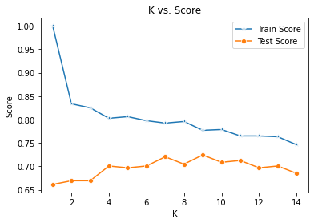

```python
sns.lineplot(x=range(1,15), y=train_scores, marker='*', label='Train Score')
sns.lineplot(x=range(1,15), y=test_scores, marker='o', label='Test Score')
plt.title('K vs. Score')
plt.xlabel('K')
plt.ylabel('Score')
plt.show()
```

We choose 7 as the KNN threshold.

```python
knn = KNeighborsClassifier(7)

knn.fit(Proj_train_data,y_to_train)
knn.score(Proj_test_data,y_to_test)
```

```
0.7204724409448819
```

```python
predictions = knn.predict(Proj_test_data)
print(classification_report(y_to_test,predictions))
print(confusion_matrix(y_to_test,predictions))
```

```
              precision    recall  f1-score   support

           0       0.82      0.92      0.87        66
           1       0.52      0.67      0.59        55
           2       0.67      0.44      0.53        72
           3       0.87      0.87      0.87        61

    accuracy                           0.72       254
   macro avg       0.72      0.73      0.72       254
weighted avg       0.72      0.72      0.71       254

[[61  1  0  4]
 [ 1 37 15  2]
 [ 8 30 32  2]
 [ 4  3  1 53]]
```

Next, we'll train using Random Forests.

```python
from sklearn.tree import DecisionTreeClassifier

clf_gini = DecisionTreeClassifier(criterion='gini', max_depth=3, random_state=0)
clf_gini.fit(Proj_train_data,y_to_train)
```

```
DecisionTreeClassifier(max_depth=3, random_state=0)
```

```python
from sklearn.metrics import accuracy_score

y_pred_gini = clf_gini.predict(Proj_test_data)
print('Model accuracy score with criterion gini index: {0:0.4f}'.format(accuracy_score(y_to_test, y_pred_gini)))
```

```
Model accuracy score with criterion gini index: 0.5669
```

```python
y_pred_train_gini = clf_gini.predict(Proj_train_data)
print('Training set score: {:.4f}'.format(clf_gini.score(Proj_train_data, y_to_train)))
print('Test set score: {:.4f}'.format(clf_gini.score(Proj_test_data, y_to_test)))
```

```
Training set score: 0.6175
Test set score: 0.5669
```

```python
from sklearn.ensemble import RandomForestClassifier

rfc = RandomForestClassifier(n_estimators=100)
rfc.fit(Proj_train_data,y_to_train)
```

```
RandomForestClassifier()
```

```python
rfc_pred = rfc.predict(Proj_test_data)
print('Model accuracy score: {0:0.4f}'.format(accuracy_score(y_to_test, rfc_pred)))
```

```
Model accuracy score: 0.6929
```

```python
print(confusion_matrix(y_to_test,rfc_pred))
print(classification_report(y_to_test, rfc_pred))
```

```
[[58  6  0  2]
 [ 2 35 15  3]
 [ 9 34 26  3]
 [ 1  3  0 57]]
              precision    recall  f1-score   support

           0       0.83      0.88      0.85        66
           1       0.45      0.64      0.53        55
           2       0.63      0.36      0.46        72
           3       0.88      0.93      0.90        61

    accuracy                           0.69       254
   macro avg       0.70      0.70      0.69       254
weighted avg       0.70      0.69      0.68       254
```

```python
from sklearn.model_selection import RandomizedSearchCV

random_grid = {'n_estimators':  [int(x) for x in np.linspace(start = 200, stop = 2000, num = 10)],
               'max_features':  ['auto', 'sqrt'],
               'max_depth': [int(x) for x in np.linspace(10, 110, num = 11)],
               'min_samples_split':  [2, 5, 10],
               'min_samples_leaf':  [1, 2, 4],
               'bootstrap': [True, False]}

rfc_random_grid = RandomizedSearchCV(estimator = rfc, param_distributions = random_grid, n_iter = 100, cv = 3, verbose=3, random_state=42, n_jobs = -1)
rfc_random_grid.fit(Proj_train_data, y_to_train)
```

```
Fitting 3 folds for each of 100 candidates, totalling 300 fits
```

```
RandomizedSearchCV(cv=3, estimator=RandomForestClassifier(), n_iter=100,
                   n_jobs=-1,
                   param_distributions={'bootstrap': [True, False],
                                        'max_depth': [10, 20, 30, 40, 50, 60,
                                                      70, 80, 90, 100, 110],
                                        'max_features': ['auto', 'sqrt'],
                                        'min_samples_leaf': [1, 2, 4],
                                        'min_samples_split': [2, 5, 10],
                                        'n_estimators': [200, 400, 600, 800,
                                                         1000, 1200, 1400, 1600,
                                                         1800, 2000]},
                   random_state=42, verbose=3)
```

```python
print(rfc_random_grid.best_estimator_)
```

```
RandomForestClassifier(max_depth=10, n_estimators=1800)
```

```python
improved_grid = {'n_estimators':  [100, 150, 200, 250, 300, 350, 400],
               'max_features':  ['auto', 'sqrt'],
               'max_depth': [100, 110, 120, 130, 140],
               'min_samples_split':  [2, 5, 10],
               'min_samples_leaf':  [1, 2, 4],
               'bootstrap': [True, False]}

rfc_improved = RandomizedSearchCV(estimator = rfc, param_distributions = improved_grid, verbose=3, random_state=42, refit = True)
rfc_improved.fit(Proj_train_data, y_to_train)
print(rfc_improved.best_estimator_)
```

```
Fitting 5 folds for each of 10 candidates, totalling 50 fits
[CV 1/5] END bootstrap=False, max_depth=130, max_features=sqrt, min_samples_leaf=4, min_samples_split=5, n_estimators=400;, score=0.752 total time=   0.8s
[CV 2/5] END bootstrap=False, max_depth=130, max_features=sqrt, min_samples_leaf=4, min_samples_split=5, n_estimators=400;, score=0.692 total time=   0.7s
[CV 3/5] END bootstrap=False, max_depth=130, max_features=sqrt, min_samples_leaf=4, min_samples_split=5, n_estimators=400;, score=0.769 total time=   0.8s
[CV 4/5] END bootstrap=False, max_depth=130, max_features=sqrt, min_samples_leaf=4, min_samples_split=5, n_estimators=400;, score=0.724 total time=   0.7s
[CV 5/5] END bootstrap=False, max_depth=130, max_features=sqrt, min_samples_leaf=4, min_samples_split=5, n_estimators=400;, score=0.741 total time=   0.7s
[CV 1/5] END bootstrap=False, max_depth=110, max_features=sqrt, min_samples_leaf=2, min_samples_split=10, n_estimators=400;, score=0.735 total time=   0.7s
[CV 2/5] END bootstrap=False, max_depth=110, max_features=sqrt, min_samples_leaf=2, min_samples_split=10, n_estimators=400;, score=0.692 total time=   0.7s
[CV 3/5] END bootstrap=False, max_depth=110, max_features=sqrt, min_samples_leaf=2, min_samples_split=10, n_estimators=400;, score=0.752 total time=   0.7s
[CV 4/5] END bootstrap=False, max_depth=110, max_features=sqrt, min_samples_leaf=2, min_samples_split=10, n_estimators=400;, score=0.716 total time=   0.7s
[CV 5/5] END bootstrap=False, max_depth=110, max_features=sqrt, min_samples_leaf=2, min_samples_split=10, n_estimators=400;, score=0.724 total time=   0.7s
[CV 1/5] END bootstrap=False, max_depth=130, max_features=sqrt, min_samples_leaf=4, min_samples_split=10, n_estimators=250;, score=0.752 total time=   0.4s
[CV 2/5] END bootstrap=False, max_depth=130, max_features=sqrt, min_samples_leaf=4, min_samples_split=10, n_estimators=250;, score=0.684 total time=   0.4s
[CV 3/5] END bootstrap=False, max_depth=130, max_features=sqrt, min_samples_leaf=4, min_samples_split=10, n_estimators=250;, score=0.761 total time=   0.4s
[CV 4/5] END bootstrap=False, max_depth=130, max_features=sqrt, min_samples_leaf=4, min_samples_split=10, n_estimators=250;, score=0.724 total time=   0.4s
[CV 5/5] END bootstrap=False, max_depth=130, max_features=sqrt, min_samples_leaf=4, min_samples_split=10, n_estimators=250;, score=0.716 total time=   0.4s
[CV 1/5] END bootstrap=False, max_depth=130, max_features=sqrt, min_samples_leaf=2, min_samples_split=2, n_estimators=250;, score=0.744 total time=   0.4s
[CV 2/5] END bootstrap=False, max_depth=130, max_features=sqrt, min_samples_leaf=2, min_samples_split=2, n_estimators=250;, score=0.709 total time=   0.4s
[CV 3/5] END bootstrap=False, max_depth=130, max_features=sqrt, min_samples_leaf=2, min_samples_split=2, n_estimators=250;, score=0.761 total time=   0.5s
[CV 4/5] END bootstrap=False, max_depth=130, max_features=sqrt, min_samples_leaf=2, min_samples_split=2, n_estimators=250;, score=0.698 total time=   0.5s
[CV 5/5] END bootstrap=False, max_depth=130, max_features=sqrt, min_samples_leaf=2, min_samples_split=2, n_estimators=250;, score=0.733 total time=   0.6s
[CV 1/5] END bootstrap=False, max_depth=130, max_features=auto, min_samples_leaf=2, min_samples_split=10, n_estimators=150;, score=0.744 total time=   0.2s
[CV 2/5] END bootstrap=False, max_depth=130, max_features=auto, min_samples_leaf=2, min_samples_split=10, n_estimators=150;, score=0.692 total time=   0.2s
[CV 3/5] END bootstrap=False, max_depth=130, max_features=auto, min_samples_leaf=2, min_samples_split=10, n_estimators=150;, score=0.761 total time=   0.2s
[CV 4/5] END bootstrap=False, max_depth=130, max_features=auto, min_samples_leaf=2, min_samples_split=10, n_estimators=150;, score=0.716 total time=   0.2s
[CV 5/5] END bootstrap=False, max_depth=130, max_features=auto, min_samples_leaf=2, min_samples_split=10, n_estimators=150;, score=0.716 total time=   0.2s
[CV 1/5] END bootstrap=True, max_depth=100, max_features=sqrt, min_samples_leaf=4, min_samples_split=10, n_estimators=200;, score=0.718 total time=   0.3s
[CV 2/5] END bootstrap=True, max_depth=100, max_features=sqrt, min_samples_leaf=4, min_samples_split=10, n_estimators=200;, score=0.667 total time=   0.3s
[CV 3/5] END bootstrap=True, max_depth=100, max_features=sqrt, min_samples_leaf=4, min_samples_split=10, n_estimators=200;, score=0.735 total time=   0.3s
[CV 4/5] END bootstrap=True, max_depth=100, max_features=sqrt, min_samples_leaf=4, min_samples_split=10, n_estimators=200;, score=0.690 total time=   0.3s
[CV 5/5] END bootstrap=True, max_depth=100, max_features=sqrt, min_samples_leaf=4, min_samples_split=10, n_estimators=200;, score=0.741 total time=   0.3s
[CV 1/5] END bootstrap=True, max_depth=130, max_features=sqrt, min_samples_leaf=2, min_samples_split=2, n_estimators=300;, score=0.726 total time=   0.5s
[CV 2/5] END bootstrap=True, max_depth=130, max_features=sqrt, min_samples_leaf=2, min_samples_split=2, n_estimators=300;, score=0.675 total time=   0.6s
[CV 3/5] END bootstrap=True, max_depth=130, max_features=sqrt, min_samples_leaf=2, min_samples_split=2, n_estimators=300;, score=0.752 total time=   0.5s
[CV 4/5] END bootstrap=True, max_depth=130, max_features=sqrt, min_samples_leaf=2, min_samples_split=2, n_estimators=300;, score=0.724 total time=   0.6s
[CV 5/5] END bootstrap=True, max_depth=130, max_features=sqrt, min_samples_leaf=2, min_samples_split=2, n_estimators=300;, score=0.724 total time=   0.5s
```

[output cut: 18 more lines]

```python
rfc_final = rfc_improved.best_estimator_
rfc_final.fit(Proj_train_data, y_to_train)
rfc_final_pred = rfc_final.predict(Proj_test_data)
print('Model accuracy score: {0:0.4f}'.format(accuracy_score(y_to_test, rfc_final_pred)))
print(confusion_matrix(y_to_test,rfc_final_pred))
print(classification_report(y_to_test, rfc_final_pred))
```

```
Model accuracy score: 0.7047
[[59  4  1  2]
 [ 3 38 10  4]
 [ 8 36 24  4]
 [ 0  3  0 58]]
              precision    recall  f1-score   support

           0       0.84      0.89      0.87        66
           1       0.47      0.69      0.56        55
           2       0.69      0.33      0.45        72
           3       0.85      0.95      0.90        61

    accuracy                           0.70       254
   macro avg       0.71      0.72      0.69       254
weighted avg       0.72      0.70      0.69       254
```

It seems that we're struggling to beat .75 accuracy, with Neural Networks, KNN, and Random Forest classifiers all scoring remarkably similar to each other. Part of this issue seems to be specifically the difference between the Saab 9000 (2) and the Opel Manta 400l (1). Both of these cars are sedans, and so the algorithms seem to struggle to differentiate them (looking at the middle 4 squares of the confusion matrix), whereas the bus and the van are easier to differentiate.

For curiosity's sake, let's see what the performance of neural networks (our best performing model) would be if we wanted to classify different body types of cars. That is, if we combined the classes for Open Manta 400l and Saab 9000, leaving us with a class for busses, a class for sedans, and a class for vans.

```python
y_to_train[y_to_train == 2] = 1
```

```python
# make sure it worked
y_to_train.unique()
```

```
array([1, 3, 0])
```

```python
y_to_test[y_to_test == 2] = 1
```

```python
final_mlp = MLPClassifier(max_iter=1000, hidden_layer_sizes=(1024, 512, 256), activation='relu', learning_rate='adaptive', solver='sgd')
```

```python
final_mlp.fit(Proj_train_data, y_to_train)
```

```
MLPClassifier(hidden_layer_sizes=(1024, 512, 256), learning_rate='adaptive',
              max_iter=1000, solver='sgd')
```

```python
predictions = final_mlp.predict(Proj_test_data)
```

```python
print('Model accuracy score: {0:0.4f}'.format(accuracy_score(y_to_test, predictions)))
print(confusion_matrix(y_to_test,predictions))
print(classification_report(y_to_test, predictions))
```

```
Model accuracy score: 0.9291
[[ 61   3   2]
 [  5 121   1]
 [  0   7  54]]
              precision    recall  f1-score   support

           0       0.92      0.92      0.92        66
           1       0.92      0.95      0.94       127
           3       0.95      0.89      0.92        61

    accuracy                           0.93       254
   macro avg       0.93      0.92      0.93       254
weighted avg       0.93      0.93      0.93       254
```

Much, much better performance!